# RNAseq analysis using Rmarkdown

Cankun Wang

04/27/2020

# 1 Goal

The primary goal of this study is to identify gene expression difference between conditions.

Rmarkdown reference can be found in here: [Reference](https://rstudio.com/wp-content/uploads/2015/03/rmarkdown-reference.pdf)

How to experimental design in DESeq2 (https://rpubs.com/ge600/deseq2)

[Mathematics in Rmarkdown](https://www.calvin.edu/~rpruim/courses/s341/S17/from-class/MathinRmd.html)

[Analyzing RNA-seq data with DESeq2](http://bioconductor.org/packages/release/bioc/vignettes/DESeq2/inst/doc/DESeq2.html#independent-hypothesis-weighting)

[RNA-seq workflow: gene-level exploratory analysis and differential expression](http://bioconductor.org/packages/release/bioc/vignettes/IHW/inst/doc/introduction_to_ihw.html#an-example-rna-seq-differential-expression)

Limma is actually better than DESeq2 in terms of controlling false positives: [RNA-seq analysis is easy as 1-2-3 with limma, Glimma and edgeR](https://www.bioconductor.org/packages/devel/workflows/vignettes/RNAseq123/inst/doc/limmaWorkflow.html)

# 2 Methods

- Differential expression (DE) analysis was performed using the DESeq2 package. Genes were ranked for evidence of DE by their adjusted P values (smallest to largest). The table shows differentially expressed genes with absolute log fold-change > 1.5
- The identified differentially expressed genes with absolute log fold-change > 1.5 and Benjamini–Hochberg adjusted P values < 0.05 were submited to Enrichr v2.1 R package for enrichment analysis. The term databases are KEGG_2019_Mouse, GO_Molecular_Function_2018, GO_Biological_Process_2018, GO_Cellular_Component_2018 provided in Enrichr.
- Plots were generated using ggplot2 R package.

# 3 Pre-processing

## 3.1 Load dataset

Using raw read count as input.

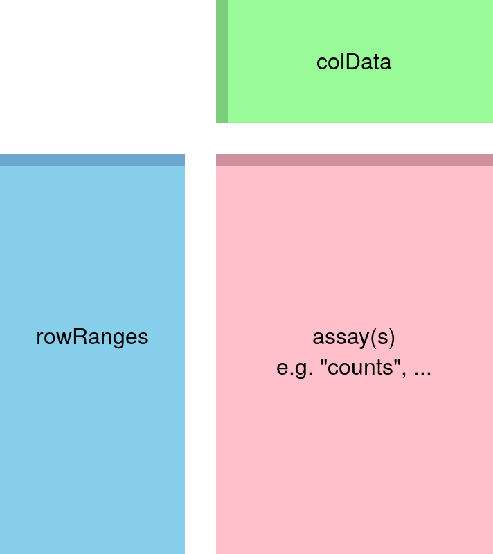

RNA-seq count matrix

```
##         S5_pool2 S2_pool2 S1_pool1 S7_pool2 S12_pool1 S6_pool1 S7_pool1
## Tex2        3459     3237     2344     2391      2154     2698     3217
## Acsf2       1329     1081     1011     2043       634      560     1237
## Gm42972        6        4        0        2         0        4        5
## Cox14       1809     2654     1148     1749      1343     1806     1793
## Crtap       1771     3669     1272     2041      1737     2504     1895
## Lsr         1124      868     1524     1165       699      663     1393
## Phf7         432      477      219      345       210      342      333
## Homer1      1101      968      779     1046       689      787     1081
## Eif4e3      1356     1753      403      893      1332      911     1624
## Cfl1       10119    20036    10518    20481     10894    16220     9493
##         S6_pool2 S2_pool1 S11_pool2
## Tex2        2102     2459      1889
## Acsf2       1233      955       553
## Gm42972        4        0        32
## Cox14       1812     1629      1607
## Crtap       3366     2196       946
## Lsr          509     1402       272
## Phf7         386      297       207
## Homer1       726     1054       772
## Eif4e3      1103      771      1674
## Cfl1       16688    17860      7566
```

```
##         Name sample injury time  skin
## 1   S5_pool2     3u    SCI 7dpw   con
## 2   S2_pool2    17u    SCI 7dpw   con
## 3   S1_pool1     8u    lam 3dpw   con
## 4   S7_pool2     2u    lam 7dpw   con
## 5  S12_pool1    13w    SCI 3dpw wound
## 6   S6_pool1    10w    lam 3dpw wound
## 7   S7_pool1    11u    SCI 3dpw   con
## 8   S6_pool2     3w    SCI 7dpw wound
## 9   S2_pool1     8w    lam 3dpw wound
## 10 S11_pool2    23w    lam 7dpw wound
```

## 3.2 Load dataset in DESeq2

# 4 Discovery driven analysis

## 4.1 Principle component analysis

Related to the distance matrix is the PCA plot, which shows the samples in the 2D plane spanned by their first two principal components. PCA plot is used for visualizing the overall effect of experimental covariates and batch effects.

### 4.1.1 PCA plot colored by injury

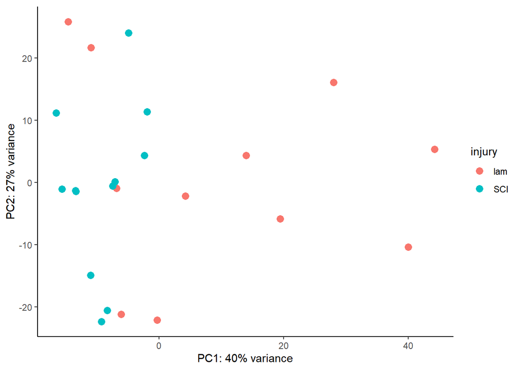

### 4.1.2 PCA plot colored by time

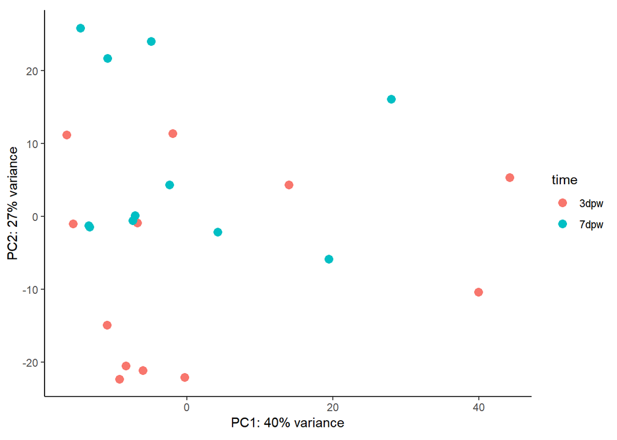

### 4.1.3 PCA plot colored by skin

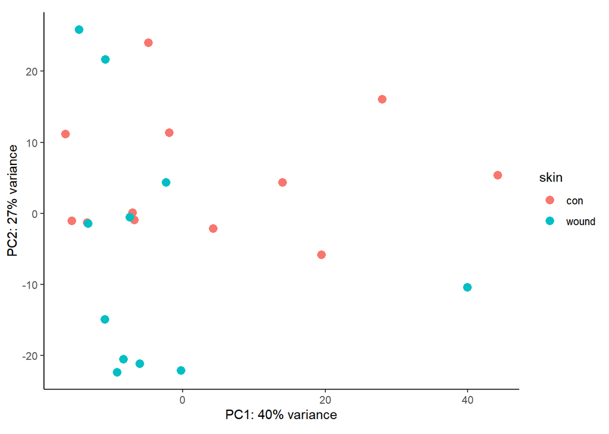

### 4.1.4 PCA plot based on color for time, shape for skin, size for injury

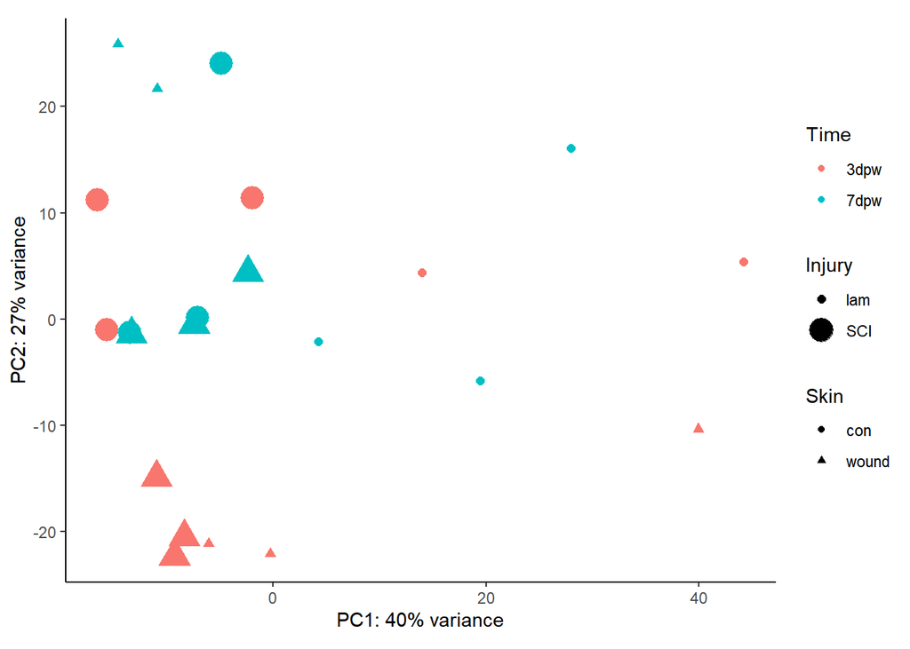

## 4.2 Sample correlation heatmap

The heatmap shows the sample-sample correlation matrix.

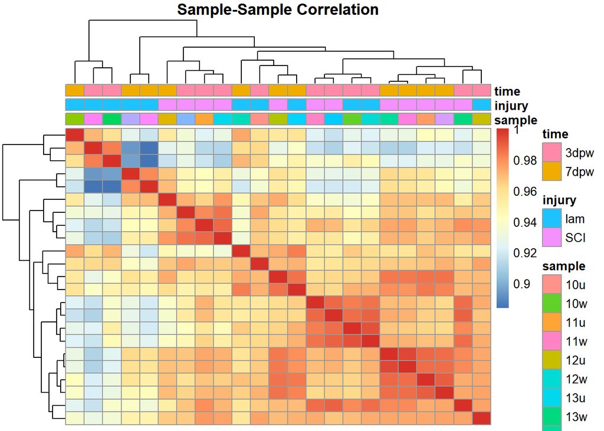

## 4.3 Sample distance heatmap

The heatmap shows the sample-sample distance matrix. The dendrogram at the side shows us a hierarchical clustering of the samples

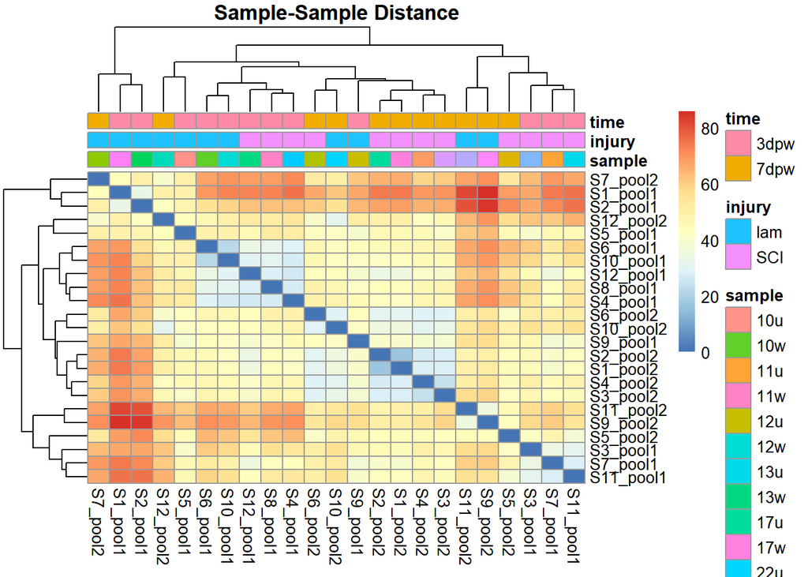

## 4.4 Heatmap of the 30 most expressed IDs

The values in the heatmap are the normalized gene expression value minus the mean value for each gene.

```
##  [1] "Acta1"   "Aldoa"   "Gm28661" "Gm10925" "Eef2"    "Lor"     "mt-Co2"
##  [8] "Perp"    "Gm28437" "Rplp0"   "mt-Nd5"  "Pkm"     "Psap"    "Sbsn"
## [15] "Calm4"   "Ptma"    "Eif4g2"  "Asprv1"  "Rplp1"   "Anxa2"   "Rpl5"
## [22] "Col17a1" "Tnni2"   "Rpl13"   "Dcn"     "Eef1g"   "Krtdap"  "Krt6a"
## [29] "Pygm"    "Mybpc2"
```

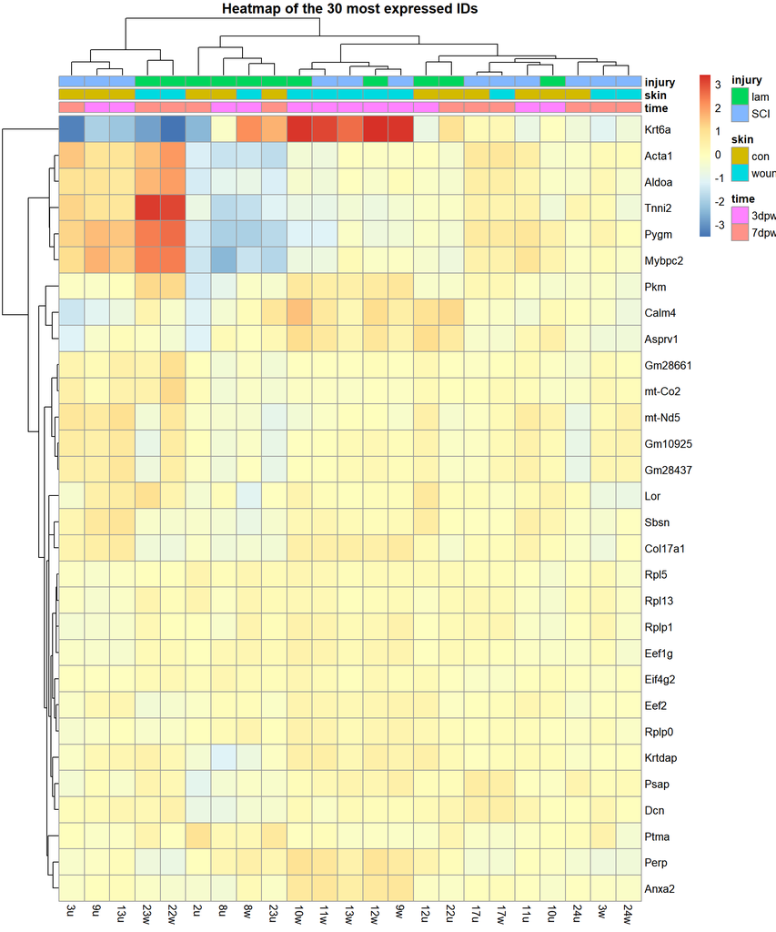

# 5 Diffrential gene expression analysis

The first column, baseMean, is a just the average of the normalized count values, divided by the size factors, taken over all samples in the DESeqDataSet.

The column log2FoldChange is the effect size estimate. It tells us how much the gene’s expression seems to have changed due to treatment in comparison to untreated samples. In another words, This value is reported on a logarithmic scale to base 2: for example, a log2 fold change of 1.5 means that the gene’s expression is increased by a multiplicative factor of $2^{1.5} \approx 2.82$.

lfcSE, the standard error estimate for the log2 fold change estimate, meaning its uncertainty associated with fold changes.

The purpose of a test for differential expression is to test whether the data provides sufficient evidence to conclude that this value is really different from zero. DESeq2 performs for each gene a hypothesis test to see whether evidence is sufficient to decide against the **null hypothesis that there is zero effect of the treatment on the gene and that the observed difference between treatment and control was merely caused by experimental variability**. As usual in statistics, the result of this test is reported as a p value, and it is found in the column pvalue. **Remember that a p value indicates the probability that a fold change as strong as the observed one, or even stronger, would be seen under the situation described by the null hypothesis**.

## 5.1 7 dpw lam wound tissues vs sci wound tissues

```
##
## out of 4000 with nonzero total read count
## adjusted p-value < 0.05
## LFC > 0 (up)       : 754, 19%
## LFC < 0 (down)     : 789, 20%
## outliers [1]       : 1, 0.025%
## low counts [2]     : 0, 0%
## (mean count < 0)
## [1] see 'cooksCutoff' argument of ?results
## [2] see 'independentFiltering' argument of ?results
```

|  | baseMean | log2FoldChange | lfcSE | stat | pvalue | padj |
| --- | --- | --- | --- | --- | --- | --- |
| Me1 | 13010.8340049088 | 2.40475870008469 | 0.118288350843212 | 20.3296324865678 | 7.03272329092371e-92 | 2.81238604404039e-88 |
| Acaca | 5652.81913578689 | 2.44362429551747 | 0.132850416585288 | 18.3938022802413 | 1.4727943806197e-75 | 2.94485236404908e-72 |
| Jsrp1 | 5805.50352649905 | 3.081274278645 | 0.241867270733729 | 12.7395255641561 | 3.56556464636681e-37 | 4.75289767360696e-34 |
| Vdac3-ps1 | 1202.53997340917 | 2.07068138940204 | 0.179716916632303 | 11.5219058294808 | 1.02322409955849e-30 | 1.0229682935336e-27 |
| Tmsb10 | 12018.0333976152 | -1.84963218090524 | 0.172715147846547 | -10.7091485834733 | 9.22058958324264e-27 | 7.37462754867746e-24 |
| Tnni2 | 84992.6806374721 | 3.43170607884323 | 0.325383283846604 | 10.5466575857076 | 5.26363771478463e-26 | 3.50821453690395e-23 |
| Jtb | 1996.91057395676 | 0.981140618551437 | 0.0951582197073497 | 10.3106239436682 | 6.30903755790149e-25 | 3.60426302772115e-22 |
| Mtfp1 | 380.614365133488 | 2.37184379929562 | 0.235309365044253 | 10.0796829690547 | 6.79449930965945e-24 | 3.39640034241602e-21 |
| Myh3 | 4096.31865061799 | -3.07102696644 | 0.306174078195601 | -10.0303297540364 | 1.12141454383833e-23 | 4.98281862312165e-21 |
| Mymx | 191.482841291293 | -5.39159377460669 | 0.542310073423468 | -9.94190231535052 | 2.73552489175133e-23 | 1.09393640421136e-20 |

[output cut: 3990 more lines]

### 5.1.1 MA-plot

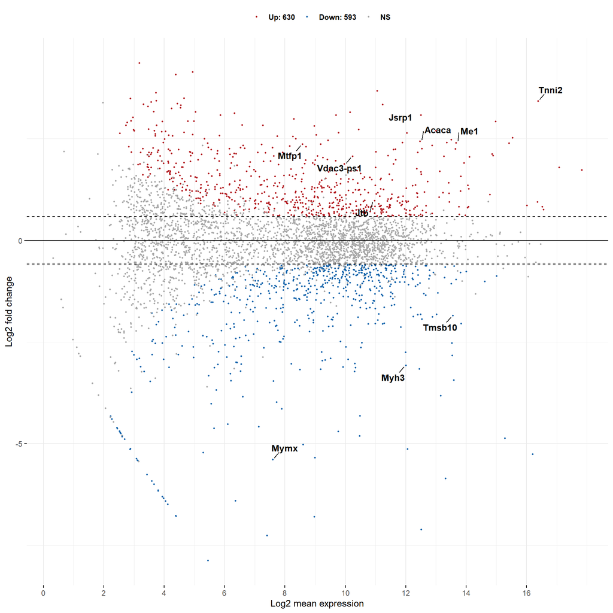

### 5.1.2 Volcano-plot

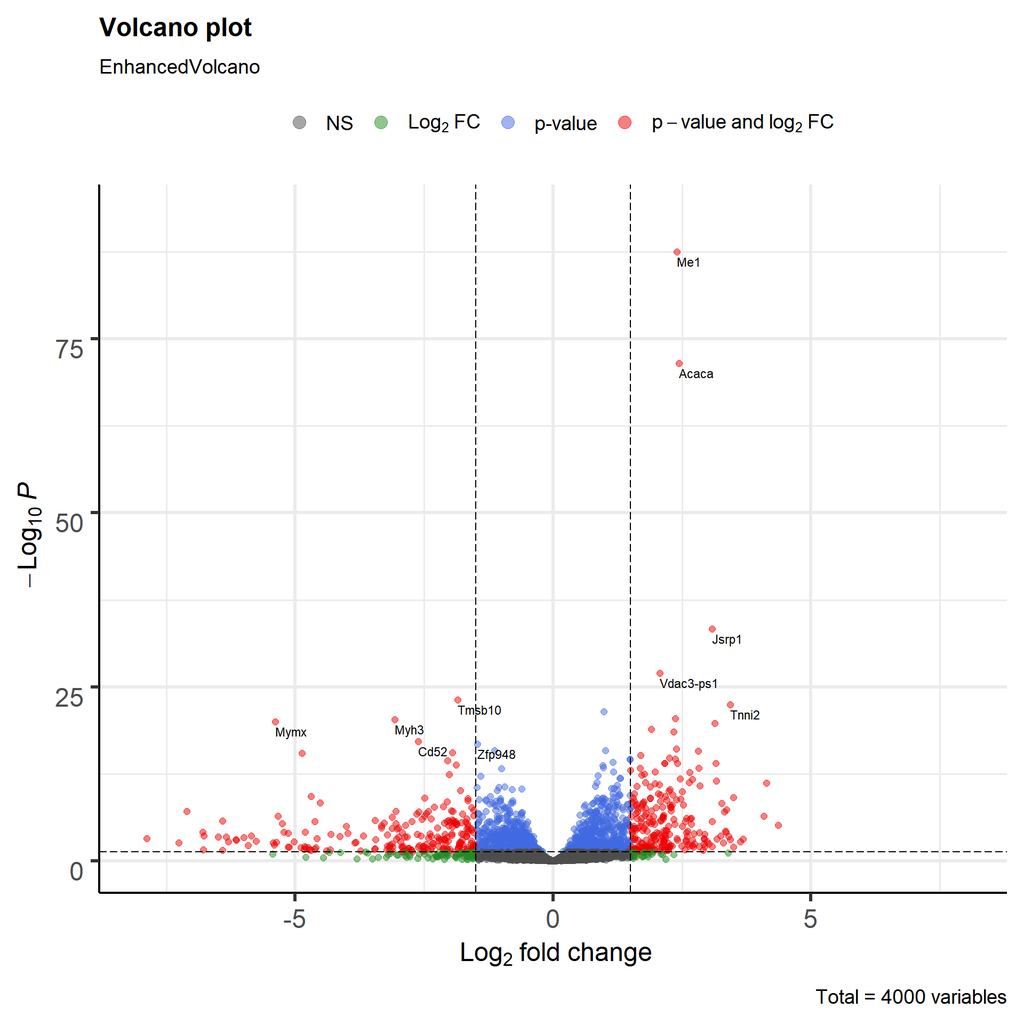

### 5.1.3 Functional enrichment analysis for DEGs, with adj.p.value<0.05

#### 5.1.3.1 GO Biological Process

```
## Uploading data to Enrichr... Done.
##   Querying GO_Molecular_Function_2018... Done.
##   Querying GO_Cellular_Component_2018... Done.
##   Querying GO_Biological_Process_2018... Done.
##   Querying KEGG_2019_Mouse... Done.
## Parsing results... Done.
```

|  | Term | Overlap | Adjusted.P.value | Combined.Score | Genes |
| --- | --- | --- | --- | --- | --- |
| 1 | striated muscle contraction (GO:0006941) | 8/61 | 0.00311986450085757 | 157.680667732526 | MYLK2;MYBPC2;JSRP1;TNNI2;ALDOA;LMOD3;MYOM2;KLHL41 |
| 2 | muscle contraction (GO:0006936) | 11/137 | 0.00194724011268829 | 95.0399118560013 | TMOD1;MYLK2;ACTA1;MYH2;MYBPC2;HRC;TNNI2;ALDOA;KLHL41;MYOM2;LMOD3 |
| 3 | myofibril assembly (GO:0030239) | 7/47 | 0.00220683803853051 | 169.651641203344 | TMOD1;MYLK2;MYBPC2;MYOZ1;MYOM2;LMOD3;KLHL41 |
| 4 | regulation of calcium ion transmembrane transporter activity (GO:1901019) | 5/27 | 0.0190267704153739 | 172.941142891306 | CACNB1;JSRP1;PDE4D;HRC;JPH1 |
| 5 | muscle fiber development (GO:0048747) | 5/27 | 0.0152214163322992 | 172.941142891306 | ACTA1;NEXN;MYOM2;LMOD3;KLHL41 |
| 6 | actomyosin structure organization (GO:0031032) | 7/71 | 0.018312976203897 | 89.0304043087863 | TMOD1;MYLK2;MYBPC2;MYOZ1;LMOD3;MYOM2;KLHL41 |
| 7 | striated muscle cell development (GO:0055002) | 4/20 | 0.0594475275966889 | 158.224117254848 | TMOD1;MYOZ1;KLHL41;LMOD3 |
| 8 | muscle filament sliding (GO:0030049) | 5/38 | 0.0531684511763122 | 103.852636233171 | TMOD1;ACTA1;MYH2;MYBPC2;TNNI2 |
| 9 | actin-myosin filament sliding (GO:0033275) | 5/38 | 0.0472608454900552 | 103.852636233171 | TMOD1;ACTA1;MYH2;MYBPC2;TNNI2 |
| 10 | skeletal muscle tissue development (GO:0007519) | 5/39 | 0.0483200060535562 | 99.8158628328481 | MYLK2;ACTA1;SIX1;LMOD3;KLHL41 |

[output cut: 10 more lines]

#### 5.1.3.2 GO Cellular Component

|  | Term | Overlap | Adjusted.P.value | Combined.Score | Genes |
| --- | --- | --- | --- | --- | --- |
| 1 | striated muscle thin filament (GO:0005865) | 5/19 | 0.00103550988435917 | 286.89032029412 | TMOD1;ACTA1;MYBPC2;MYOM2;LMOD3 |
| 2 | contractile fiber (GO:0043292) | 4/26 | 0.0530538127989298 | 107.86839452057 | TMOD1;MYH2;PDE4DIP;LMOD3 |
| 3 | myofibril (GO:0030016) | 4/27 | 0.0411348055233069 | 101.993244064629 | TMOD1;MYH2;PDE4DIP;LMOD3 |
| 4 | sarcoplasmic reticulum (GO:0016529) | 4/29 | 0.0409804141248983 | 91.6683352255672 | JSRP1;S100A1;HRC;JPH1 |
| 5 | sarcoplasm (GO:0016528) | 3/31 | 0.52175996392903 | 41.811564182654 | JSRP1;S100A1;JPH1 |
| 6 | Cul3-RING ubiquitin ligase complex (GO:0031463) | 4/70 | 0.721895018099069 | 22.2541898571355 | KBTBD13;KLHL33;KLHL34;KLHL41 |
| 7 | actin cytoskeleton (GO:0015629) | 8/294 | 1 | 8.44345502605712 | TMOD1;ACTA1;MYBPC2;MYOZ1;ALDOA;MYOM2;ACACA;LMOD3 |
| 8 | MICOS complex (GO:0061617) | 1/6 | 1 | 37.3817853660503 | APOO |
| 9 | junctional sarcoplasmic reticulum membrane (GO:0014701) | 1/9 | 1 | 21.2998382392354 | JPH1 |
| 10 | actin filament (GO:0005884) | 2/55 | 1 | 6.0238947624491 | TMOD1;ACTA1 |

[output cut: 10 more lines]

#### 5.1.3.3 GO Molecular Function

|  | Term | Overlap | Adjusted.P.value | Combined.Score | Genes |
| --- | --- | --- | --- | --- | --- |
| 1 | ATPase binding (GO:0051117) | 4/63 | 1 | 26.6851617674295 | S100A1;PDE4D;HRC;SVIP |
| 2 | actin binding (GO:0003779) | 8/254 | 1 | 11.8574526206546 | TMOD1;MYBPC2;NEXN;TNNI2;MYOZ1;ALDOA;MYOM2;LMOD3 |
| 3 | tropomyosin binding (GO:0005523) | 2/14 | 1 | 53.4216790310984 | TMOD1;LMOD3 |
| 4 | aldehyde dehydrogenase (NAD) activity (GO:0004029) | 2/14 | 1 | 53.4216790310984 | ALDH1L1;ALDH1A1 |
| 5 | 3',5'-cyclic-AMP phosphodiesterase activity (GO:0004115) | 2/15 | 1 | 48.344329323115 | PDE4D;PDE4C |
| 6 | muscle alpha-actinin binding (GO:0051371) | 2/16 | 1 | 44.0020871756262 | MYBPC2;MYOM2 |
| 7 | 3',5'-cyclic-nucleotide phosphodiesterase activity (GO:0004114) | 2/20 | 1 | 31.6015465518003 | PDE4D;PDE4C |
| 8 | sialyltransferase activity (GO:0008373) | 2/21 | 1 | 29.357828147761 | ST8SIA5;ST3GAL3 |
| 9 | Wnt-activated receptor activity (GO:0042813) | 2/22 | 1 | 27.3544897757577 | FRZB;SFRP5 |
| 10 | NAD binding (GO:0051287) | 2/22 | 1 | 27.3544897757577 | ALDH1A1;ME1 |

[output cut: 10 more lines]

#### 5.1.3.4 KEGG pathway

|  | Term | Overlap | Adjusted.P.value | Combined.Score | Genes |
| --- | --- | --- | --- | --- | --- |
| 1 | Pentose phosphate pathway | 4/32 | 0.163962485492036 | 79.0110339268243 | ALDOA;TKT;PFKM;FBP2 |
| 2 | AMPK signaling pathway | 6/126 | 0.607635457651883 | 22.0838966707225 | IRS3;MLYCD;PPARGC1A;PFKM;ACACA;FBP2 |
| 3 | Insulin signaling pathway | 6/139 | 0.65065730511566 | 18.2995926676196 | SHC3;PYGM;IRS3;PPARGC1A;ACACA;FBP2 |
| 4 | Fructose and mannose metabolism | 3/35 | 0.62308947409696 | 34.5774568794461 | ALDOA;PFKM;FBP2 |
| 5 | Morphine addiction | 4/92 | 1 | 13.5948940383983 | PDE4D;PDE4C;ADORA1;GNG13 |
| 6 | Insulin resistance | 4/110 | 1 | 9.65022622361328 | SLC27A1;PYGM;PPARGC1A;AGT |
| 7 | Glycolysis / Gluconeogenesis | 3/67 | 1 | 11.6093529179104 | ALDOA;PFKM;FBP2 |
| 8 | Propanoate metabolism | 2/31 | 1 | 15.9962091459279 | MLYCD;ACACA |
| 9 | Adipocytokine signaling pathway | 3/71 | 1 | 10.4492549448623 | IRS3;RXRG;PPARGC1A |
| 10 | beta-Alanine metabolism | 2/32 | 1 | 15.1976675577059 | SMS;MLYCD |

[output cut: 10 more lines]